# La vulnerabilidad de las contraseñas de redes sociales hoy en día desde la generación centenial hasta la Generación X de la población de Lima metropolitana

2023-06-04

| **INTEGRANTES** | **CÓDIGO** | **PARTICIPACIÓN** |
| --- | --- | --- |
| Valeria Arana Uzátegui | 202110015 | 100% |
| Gabriel Blanco Gutierrez | 202210049 | 100% |
| Katherine Lopez Villano | 202220312 | 100% |
| José Barrenechea Merino | 202110512 | 100% |
| Cristian Flores Pérez | 202120222 | 15% |

# **INTRODUCCIÓN**

Hoy en día vivimos en un mundo más conectado y dependiente de las redes sociales, estas pueden ser nuestras mejores alidas como tambien algo perjudicial para nosotros. Aplicaciones como Whattssap, facebook e Instagram nos permiten estar informados permamentemente de lo que pasa en todo el mundos. Sin embargo al crear una cuenta en estas apliciones corremos el riesgo a ser hackeados, ya que estas aplicaciones pueden acceder a una base de datos en donde se encuentran todos nuestros datos personales.

- **RELEVANCIA** Conocer la brecha tecnológica en cuanto a seguridad en sus cuentas de instagram en la generacion centenial hasta la generación X. Asimismo, este estudio estadístico busca informar a las personas sobre la seguridad de sus cuentas de Instagram.

# **OBJETIVOS**

## - **General**

Comparar la calidad de seguridad entre las contraseñas creadas por personas de la generación centenial hasta la generación X.

## - **Específico**

Determinar que generación presenta una mayor seguridad al crear su cuenta de de red social

Analizar la influencia que tiene la edad de los participantes al momento de establecer una contraseña de seguridad en sus cuentas de red social.

Demostrar que la generación X es la más propensa a ser hackeada.

Determinar la relación entre cantidad de caracteres y la seguridad en sus cuentas de red social.

# **DATOS**

## **Proceso de recolección de datos**

En esta oportunidad la recolección de datos se dará a través de una encuesta enfocada en el rango poblacional elegido. Se utilizará la herramienta de Google Forms, debido a su sencilla elaboración. Asimismo, nos permitirá descargar los datos obtenidos en formato csv.

En cuanto al rango de tiempo para la recolección de datos se dió desde el 30 de abril hatsa el 5 mayo del 2023.

## **Población de muestra y muestreo**

- **Población:**Generación centenial hasta la generación X.
- **Muestra:** Generación centenial hasta la generación X que usen instagram.
- **Unidad muestral:** Una persona de la generación centenial, milenial y X que utilice instagram.
- **Muestreo:** Muestreo Probabilístico aleatorio Simple.

## **Variables**

| **Variables** | **Tipo de variable** |
| --- | --- |
| Edad | cuantitativa discreta |
| Cantidad de redes sociales | cuantativa discreta |
| Cantidad de caracteres de la contraseña | cuantitiva discreta |
| Características de la contraseña | cualitativa nominal |
| Cantidad de veces hackeado | cuantitiva discreta |
| Nivel de seguridad | cualitativa ordinal |
| Frecuencia con la que utiliza más seguido redes sociales | cualitativa ordinal |
| Tipo Generación | cualitativa nominal |
| Género | cualitativa nominal |
| Tiempo que lleva instalado redes sociales | cuantitativa continua |
| Tiempo en horas al día que utiliza Instagram | cuantitativa discreta |
| Espectro de seguidores | cualitativa ordinal |
| Tiempo que cambias la contraseña de redes sociales | cuantitativa continua |

# **INSTALAMOS LIBRERÍAS**

```r
#install.packages("readr")
```

```r
#install.packages("readr")
```

```r
library("ggplot2")
library(stringr)
library(dplyr)
library(readr)
```

```r
cv <- function(X){
  return (sd(X, na.rm = T)/mean(X, na.rm = T))
}
```

```r
r <- function(n){
  round(n ,2)
}
```

```r
#install.packages("stringr")
```

```r
#install.packages("ggplot2")
```

## **Remonbramos la base de datos y leemos datos de la data**

```r
VDC=read.csv("~/Documents/GENERALES UTEC/ESTADÍSTICA/PROYECTO ESTADISTICA/_LA VULNERABILIDAD DE LAS CONTRASEÑAS DE INSTAGRAM  (respuestas) - Respuestas de formulario 1.csv")
```

```r
ncol(VDC) # leer el número de columnas(variables)
```

```
## [1] 16
```

```r
nrow(VDC) # leer la cantidad de filas (obervaciones o número de unidades elemetales)
```

```
## [1] 262
```

```r
dim(VDC) # Devuelve las dimensiones de la base de datos (f*c)
```

```
## [1] 262  16
```

```r
#str(VDC) # Resuemen del tipo de variable de la base de datos
```

```r
#summary(VDC) #Resumen general de la base de datos
```

# **LIMPIEZA DE DATOS**

#### Renombramos la data:

```r
VDC= rename(VDC,Edad = 'Edad.en.años.cumplidos...ejemplo..19..',Genero='Género..elegir.solo.una.opción.',Generacion = 'X.A.qué.generación.pertenece....importante..elegir.solo.una.opción.', Generacion= 'X.A.qué.generación.pertenece....importante..elegir.solo.una.opción.',RedesSociales='X.Cantidad.de.redes.sociales.que.utiliza.actualmente....Ejemplo..4.',  Tiempoinstalado= 'X.Desde.hace.cuánto.tiempo..en.años..utiliza.redes.sociales....Inserte.un.número.entero.o.decimal.', Seguidores='X.Cuántos.seguidores.tiene.en.sus.redes.sociales.aproximadamente.o.la.red.social.que.utiliza.más.seguido....Inserte.un.número.', Tiempodeuso= 'X.En.qué.momento.del.día.utiliza.más.seguido.redes.Sociales...elegir.solo.una.opción.', Canticaracteres ='X.Cuántos.caracteres.en.promedio.tienen.sus.contraseñas.de.redes.sociales...Inserte.un.número..Ejemplo..5',TipoCaracteres ='X.Qué.caracteres.contiene.generalmente.sus.contraseñas.de.redes.sociales...puede.seleccionar.más.de.una.opción.',Nseguridad = 'X.Considera.que.la.contraseñas.de.su.cuenta.de.red.social.es.segura...siendo.1..No.segura.y.5..Muy.segura.',Usodecontraseña= 'X.Prefiere.utilizar.una..misma.contraseña.para.ingresar.a.todas.sus.redes.sociales...elija.solo.una.opción.', Tcambiocontraseña = 'Hace.algunos.días.Facebook.publicó.en.su.blog.oficial.una.infografía.en.la.que.se.estima.que.a.diario.600.00.cuentas.de.Facebook.han.estado.en.peligro.de.ser.hackeadas....Sabiendo.esa.noticia.y.sobre.los.peligros.del.hackeo.en.redes.sociales..cada.cuánto.tiempo.en.días..cambiarías.tu.contraseña..',Cuentahackeada='X.Su.cuenta.ha.sido.hackeada.anteriormente...elija.solo.una.opción.', Numnotificaciones= 'X.Cada.cuántas.veces.al.día.usted.revisa.las.notificaciones.que.le.llegan.a.su.celular...inserte.un.número..Ejemplo..10'
)
```

### **Modificamos las categorías de Generacion**

```r
VDC$Generacion[VDC$Generacion == "Generación centenial ( comprende un rango de edad entre los 12 - 27 años )" ] = "Centenial"
```

```r
VDC$Generacion[VDC$Generacion == "Generación milenial  ( comprende un rango de edad entre los 28 - 41 años )"] = "Milenial"
```

```r
unique(VDC$Generacion)
```

```
## [1] "Centenial"
## [2] "Generación x ( comprende un rango de edad entre los 42 - 53 años )"
## [3] "Milenial"
```

```r
VDC$Generacion[VDC$Generacion =="Generación x ( comprende un rango de edad entre los 42 - 53 años )"] = "GX"
```

```r
names(VDC)
```

```
##  [1] "X"                 "X.1"               "Edad"
##  [4] "Genero"            "Generacion"        "RedesSociales"
##  [7] "Tiempoinstalado"   "Seguidores"        "Tiempodeuso"
## [10] "Canticaracteres"   "TipoCaracteres"    "Nseguridad"
## [13] "Usodecontraseña"   "Tcambiocontraseña" "Cuentahackeada"
## [16] "Numnotificaciones"
```

```r
#VDC
```

### **Exportar base de datos limpia**

```r
write_csv(VDC,"LIMPIOPROYECT.csv")
```

```r
VDC1 <-read_csv("~/Documents/GENERALES UTEC/ESTADÍSTICA/PROYECTO ESTADISTICA/LIMPIOPROYECT.csv")
VDC1
```

```
## # A tibble: 262 × 16
##    X     X.1    Edad Genero  Generacion RedesSociales Tiempoinstalado Seguidores
##    <lgl> <lgl> <dbl> <chr>   <chr>              <dbl>           <dbl>      <dbl>
##  1 NA    NA       18 Mascul… Centenial              4             7          500
##  2 NA    NA       19 Mascul… Centenial              2             4          600
##  3 NA    NA       18 Femeni… Centenial              4             3           75
##  4 NA    NA       20 Mascul… Centenial              5             9          100
##  5 NA    NA       46 Femeni… GX                     7            20          250
##  6 NA    NA       20 Mascul… Centenial              4             2            2
##  7 NA    NA       18 Femeni… Centenial              4             5          276
##  8 NA    NA       21 Mascul… Centenial              7             8          300
##  9 NA    NA       19 Mascul… Centenial              2             8          450
## 10 NA    NA       21 Mascul… Centenial              8             8.5        350
## # ℹ 252 more rows
## # ℹ 8 more variables: Tiempodeuso <chr>, Canticaracteres <dbl>,
## #   TipoCaracteres <chr>, Nseguridad <dbl>, Usodecontraseña <chr>,
## #   Tcambiocontraseña <dbl>, Cuentahackeada <chr>, Numnotificaciones <chr>
```

#### **Eliminamos las dos primeras columnas de variables, ya que no no contienen ningún dato**

```r
VDC1 <- VDC1 %>% select(3:16)
```

## **Aplicación de filtros**

```r
VDC1 <- VDC1 %>% filter(Edad >= 12 & Edad <= 53)
range(VDC1$Edad)
```

```
## [1] 14 53
```

Con el fin de saber los valores máximo y mínimos de la variable redes sociales aplicamos la función summary(). Dando como resultado lo siguiente.

min: 1 máx: 1234

```r
range(VDC1$RedesSociales)
```

```
## [1]    1 1234
```

Dado que el máximo valor 1234, aplicaremos el siguiente filtro, ya que no es posible que una persona tenga 1234 redes sociales generalmente tienen entre 10 a 20 redes sociales.

```r
VDC1 <- VDC1 %>% filter(RedesSociales >= 1 & RedesSociales <= 20)
```

Con el objetivo que el programa Rstudio , me lea a la variable Numnotificaciones como un `num` y no como un `chr` haremos lo siguiente….

```r
VDC1 $Numnotificaciones <-as.numeric(VDC1$Numnotificaciones, na.rm=TRUE)
VDC1$Tiempoinstalado<-as.integer(VDC1$Tiempoinstalado)
```

**Retiramos dato erróneo de Tiempo => 1900**

```r
VDC1 <- VDC1 %>% filter(Tiempoinstalado <= 22)
```

**Retiramos observaciones con dato de +400 en Canticaracteres**

```r
VDC1 <- VDC1 %>% filter(Canticaracteres <= 50)
```

```r
#str(VDC1)
```

```r
#summary(VDC1)
```

### **Exportar la base de datos utilizando “write_csv()”**

Luego de haber aplicado los filtros exportamos una nueva base de datos limpia

```r
write_csv(VDC1, "Baselimpia.csv")
```

# **ANÁLISIS DESCRIPTIVO**

```r
VDCnew <-read_csv("~/Documents/GENERALES UTEC/ESTADÍSTICA/PROYECTO ESTADISTICA/Baselimpia.csv")
VDCnew
```

```
## # A tibble: 254 × 14
##     Edad Genero  Generacion RedesSociales Tiempoinstalado Seguidores Tiempodeuso
##    <dbl> <chr>   <chr>              <dbl>           <dbl>      <dbl> <chr>
##  1    18 Mascul… Centenial              4               7        500 En la noche
##  2    19 Mascul… Centenial              2               4        600 En la noche
##  3    18 Femeni… Centenial              4               3         75 En la noche
##  4    20 Mascul… Centenial              5               9        100 En la noche
##  5    46 Femeni… GX                     7              20        250 En la noche
##  6    20 Mascul… Centenial              4               2          2 En la maña…
##  7    18 Femeni… Centenial              4               5        276 En la noche
##  8    21 Mascul… Centenial              7               8        300 En la noche
##  9    19 Mascul… Centenial              2               8        450 En la tarde
## 10    21 Mascul… Centenial              8               8        350 En la noche
## # ℹ 244 more rows
## # ℹ 7 more variables: Canticaracteres <dbl>, TipoCaracteres <chr>,
## #   Nseguridad <dbl>, Usodecontraseña <chr>, Tcambiocontraseña <dbl>,
## #   Cuentahackeada <chr>, Numnotificaciones <dbl>
```

Recordemos que: - `Generación centenial: 12-27 años` - `Generación milenial: 28-41 años` - `Generación x: 42-53`

## **Medidas de tendencia central Y gráficos**

Hallaremos la media, mediana, varianza y dsviación estándar.

para el caso de la moda usaremos los comandos: count y arrange

sabiendo ello obtendremos lo siguiente…

### **Edad:**

```r
VDCnew$Edad
```

```
##   [1] 18 19 18 20 46 20 18 21 19 21 23 19 20 18 18 19 18 19 19 19 28 19 19 19 19
##  [26] 18 20 20 19 20 19 20 18 21 18 17 18 19 18 21 44 18 23 21 18 22 18 18 17 16
##  [51] 26 18 18 25 18 22 18 18 16 21 19 23 19 19 30 19 19 19 22 16 19 23 21 17 17
##  [76] 18 20 19 17 18 18 19 18 53 18 19 53 28 18 34 52 18 51 47 52 37 46 19 22 22
## [101] 27 44 53 19 26 42 46 35 42 19 46 41 16 21 19 19 18 20 18 19 19 51 46 48 20
## [126] 18 42 39 20 19 24 18 33 27 19 20 33 21 19 17 23 18 36 19 40 46 28 28 14 31
## [151] 32 41 42 45 20 35 44 50 39 34 51 19 31 19 35 37 27 46 18 19 19 17 24 19 20
## [176] 32 52 18 49 29 48 23 49 18 18 18 18 18 19 18 19 22 22 18 18 21 22 22 50 19
## [201] 20 23 22 21 20 20 20 20 19 24 20 18 22 22 21 23 19 18 19 18 17 21 17 18 19
## [226] 22 37 39 31 22 35 19 28 20 39 46 20 18 19 34 25 19 42 18 42 37 17 19 27 19
## [251] 52 25 20 22
```

```r
max(VDCnew$Edad)
```

```
## [1] 53
```

```r
r(mean(VDCnew$Edad, na.rm = T)) #media
```

```
## [1] 25.35
```

```r
r(median(VDCnew$Edad, na.rm = T)) #mediana
```

```
## [1] 20
```

```r
r(var(VDCnew$Edad, na.rm = T)) #varianza
```

```
## [1] 108.76
```

```r
r(sd(VDCnew$Edad, na.rm = T)) #desviación estándar
```

```
## [1] 10.43
```

```r
sd(VDCnew$Edad)/ mean(VDCnew$Edad)
```

```
## [1] 0.4114445
```

El coeficiente de variación es: 0.41 -> 41%

```r
VDCnew %>% count(Edad) %>% arrange(desc(n)) %>% slice(1)
```

```
## # A tibble: 1 × 2
##    Edad     n
##   <dbl> <int>
## 1    19    52
```

Como resultado nos dió que…

```r
table(VDCnew$Edad)
```

```
##
## 14 16 17 18 19 20 21 22 23 24 25 26 27 28 29 30 31 32 33 34 35 36 37 39 40 41
##  1  4 10 48 52 23 13 15  8  3  3  2  4  5  1  1  3  2  2  3  4  1  4  4  1  2
## 42 44 45 46 47 48 49 50 51 52 53
##  6  3  1  8  1  2  2  2  3  4  3
```

### **Género**

```r
table(VDCnew$Genero)
```

```
##
##  Femenino Masculino
##       130       124
```

### **Redes sociales:**

```r
max(VDCnew$RedesSociales, na.rm = T)
```

```
## [1] 15
```

```r
r(mean(VDCnew$RedesSociales, na.rm = T))
```

```
## [1] 4.87
```

```r
r(median(VDCnew$RedesSociales, na.rm = T))
```

```
## [1] 4
```

```r
r(var(VDCnew$RedesSociales, na.rm = T))
```

```
## [1] 5.92
```

```r
r(sd(VDCnew$RedesSociales, na.rm = T))
```

```
## [1] 2.43
```

```r
VDCnew %>% count(RedesSociales) %>% arrange(desc(n)) %>% slice(1)
```

```
## # A tibble: 1 × 2
##   RedesSociales     n
##           <dbl> <int>
## 1             4    62
```

**gráfico de dispersión Redes sociales vs Edad**

Mediante este gráfico de dispersión observamos una mayor concentración en el rango de edad entre 18 a 23 aproximadamente. Sin embargo, a partir del rango de edad de 23 años en adelante observamos una menor concentración, es decir que los valores individuales están más separados o extendidos entre sí, lo que implica una mayor variabilidad o heterogeneidad en los datos.

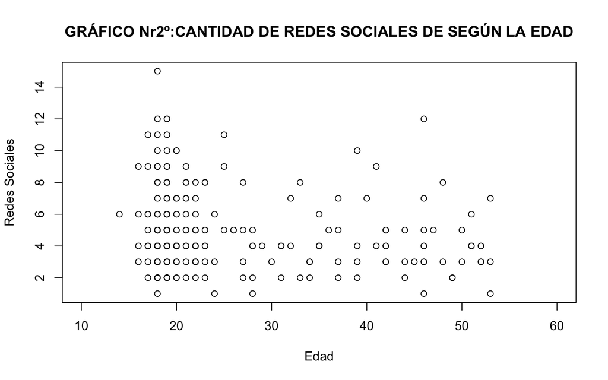

```r
plot(VDCnew$RedesSociales ~ VDCnew$Edad, xlim = c(10, 60), xlab = "Edad", ylab = "Redes Sociales", main="GRÁFICO Nr2º:CANTIDAD DE REDES SOCIALES DE SEGÚN LA EDAD")
```

Con este gráfico podemos deducir que, aparentemente, existe una correlación inversamente proporcional baja entre las variables Redes sociales(Y) y Edad(X), ya que a medida que va aumentando la edad va disminuyendo la cantidad de redes sociales que utiliza.

Usaremos el coeficiente correlación para determinar la proporcionalidad entre estas dos variables.

```r
cor(VDCnew$Edad,VDCnew$RedesSociales)
```

```
## [1] -0.154888
```

Asimismo, podemos decir que los valores 1 y -1 representan una correlación “perfecta” positiva y negativa, respectivamente.

### **Tiempo que lleva instala la aplicación:**

```r
r(mean(VDCnew$Tiempoinstalado, na.rm = T))
```

```
## [1] 8.15
```

```r
r(median(VDCnew$Tiempoinstalado, na.rm = T))
```

```
## [1] 8
```

```r
r(var(VDCnew$Tiempoinstalado, na.rm = T))
```

```
## [1] 12.98
```

```r
r(sd(VDCnew$Tiempoinstalado, na.rm = T))
```

```
## [1] 3.6
```

hallaremos la moda de la variable tiempo ….

```r
VDCnew %>% count(Tiempoinstalado) %>% arrange(desc(n)) %>% slice(1)
```

```
## # A tibble: 1 × 2
##   Tiempoinstalado     n
##             <dbl> <int>
## 1              10    52
```

Como resultado nos dió que…

- `moda es: 10`
- `numero de veces que se repite el número: 52`

**Gráfico de barras sobre la variable tiempo que lleva instalado una red social**

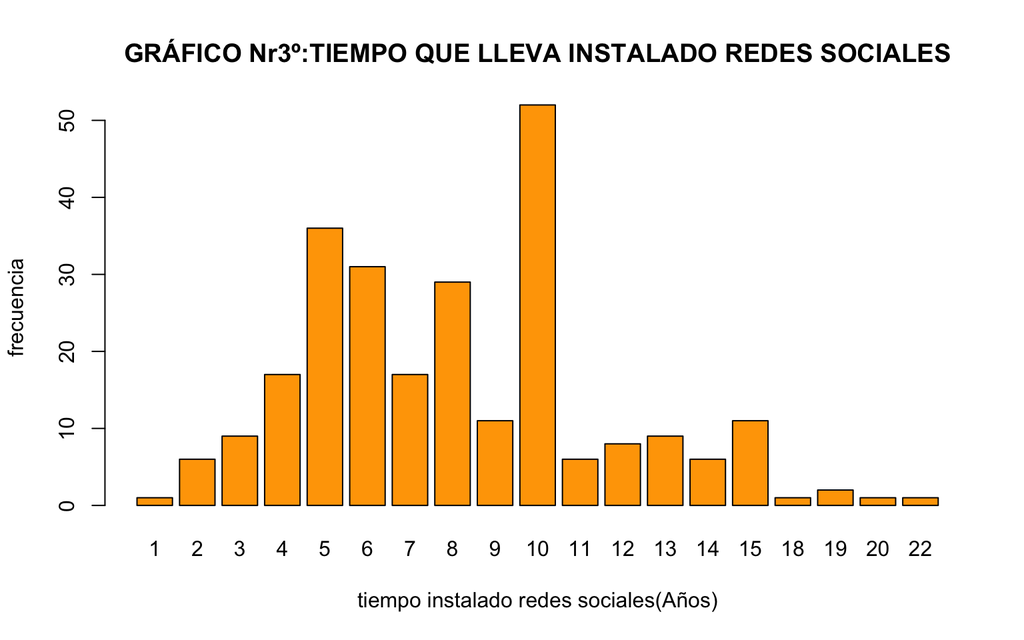

```r
barplot(table(VDCnew$Tiempoinstalado), main = "GRÁFICO Nr3º:TIEMPO QUE LLEVA INSTALADO REDES SOCIALES", xlab= "tiempo instalado redes sociales(Años)", ylab = "frecuencia", col = "orange")
```

**Gráfico de cajas y bigotes: tiempo que lleva instalado una red social según su generación**

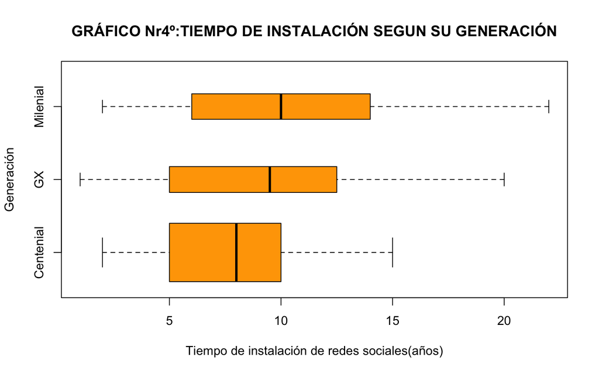

```r
boxplot(VDCnew$Tiempoinstalado ~ VDCnew$Generacion, horizontal = T, main = "GRÁFICO Nr4º:TIEMPO DE INSTALACIÓN SEGUN SU GENERACIÓN", varwidth = T, xlab = "Tiempo de instalación de redes sociales(años)", ylab = "Generación", col=c("orange"))
```

Mediante esta gráfica interpretamos que las personas de la generación centenial tienden a tener instalado sus redes sociales hace 8 años. Sin embargo, en el caso de la generación Milenial y X, la mediana nos muestra que tienden a tener instaldo redes desde hace 10 años.

### **Seguidores:**

```r
r(mean(VDCnew$Seguidores, na.rm = T))
```

```
## [1] 4623.43
```

```r
r(median(VDCnew$Seguidores, na.rm = T))
```

```
## [1] 200
```

```r
r(var(VDCnew$Seguidores, na.rm = T))
```

```
## [1] 3948851030
```

```r
r(sd(VDCnew$Seguidores, na.rm = T))
```

```
## [1] 62839.88
```

Para el caso de cantidad de seguidores observamos que tanto la desviación estándar nos salió 62839.88 como varianza 3948851030. Ello nos lleva a connotar que los valores dentro de la variable Seguidores se encuentran muy dispersos con respecto a la media. Cuanto mayor sea el valor de la desviación estándar, mayor será la dispersión de los datos.Asimismo, al ser la varianza de 3948851030 implica que los valores individuales en tu conjunto de datos están muy alejados de la media, lo que indica una gran variabilidad. Esto significa que los valores tienden a ser muy diferentes entre sí y no se agrupan cerca de la media.

Esta alta dispersion de los datos se puede reflejar mediante el siguiente codigo…

hallaremos la moda de la variable seguidores….

```r
VDCnew %>% count(Seguidores) %>% arrange(desc(n))
```

```
## # A tibble: 114 × 2
##    Seguidores     n
##         <dbl> <int>
##  1        300    22
##  2        100    21
##  3        200    16
##  4        500    11
##  5        150     9
##  6         50     8
##  7          1     7
##  8        120     6
##  9        250     5
## 10       1000     5
## # ℹ 104 more rows
```

Como resultado nos dió que…

- `moda es: 300`
- `numero de veces que se repite el número: 22`

A continuación observamos una tabla de frecuencia de la variable seguidores , con la finalidad de saber cual ha sido la frecuencia de cada valor.

```r
VDCnew %>% count(Seguidores) %>% arrange(-Seguidores)
```

```
## # A tibble: 114 × 2
##    Seguidores     n
##         <dbl> <int>
##  1    1000000     1
##  2      65156     1
##  3      10000     1
##  4       5632     1
##  5       5000     1
##  6       3000     1
##  7       2700     1
##  8       2451     1
##  9       2400     1
## 10       2000     4
## # ℹ 104 more rows
```

```r
table(VDCnew$Seguidores)
```

```
##
##     1     2     3     5     6     8    10    16    20    25    30    45    48
##     7     4     2     2     1     1     3     1     2     3     3     1     1
##    50    54    65    70    73    75    77    80    81    90    93   100   110
##     8     1     1     1     1     1     1     4     1     4     1    21     2
##   114   115   118   120   125   128   130   134   135   138   140   150   170
##     1     1     3     6     1     1     1     1     1     1     2     9     1
##   178   180   183   188   200   202   210   216   220   229   230   238   240
##     1     4     2     1    16     1     1     1     1     1     1     1     1
##   242   250   251   262   265   275   276   290   300   311   318   324   325
##     1     5     1     1     1     1     1     1    22     1     1     1     1
##   340   345   347   350   359   368   379   400   401   405   420   450   460
##     1     1     1     2     2     1     1     3     1     1     1     1     1
##   470   493   500   526   560   586   600   620   625   650   700   720   730
##     1     1    11     1     1     1     3     1     1     1     2     1     1
##   789   800   880   973  1000  1015  1100  1156  1200  1296  1394  1400  1500
##     1     2     1     1     5     1     2     1     2     1     1     1     2
##  2000  2400  2451  2700  3000  5000  5632 10000 65156 1e+06
##     4     1     1     1     1     1     1     1     1     1
```

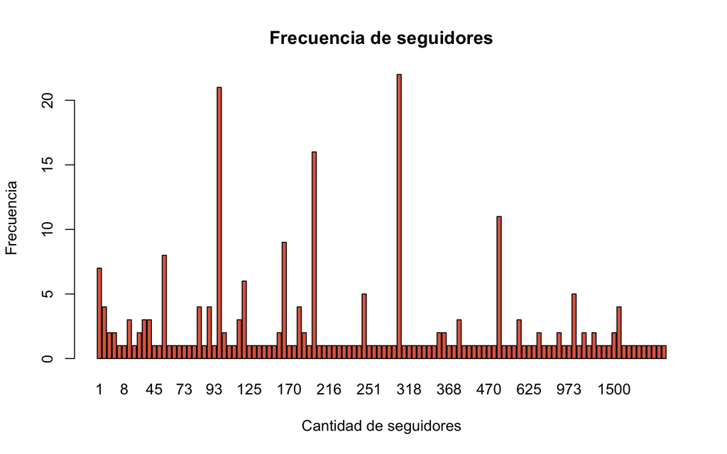

```r
barplot(table(VDCnew$Seguidores),
main = "Frecuencia de seguidores",
xlab = "Cantidad de seguidores",
ylab = "Frecuencia",
col = c("#DE6950"))
```

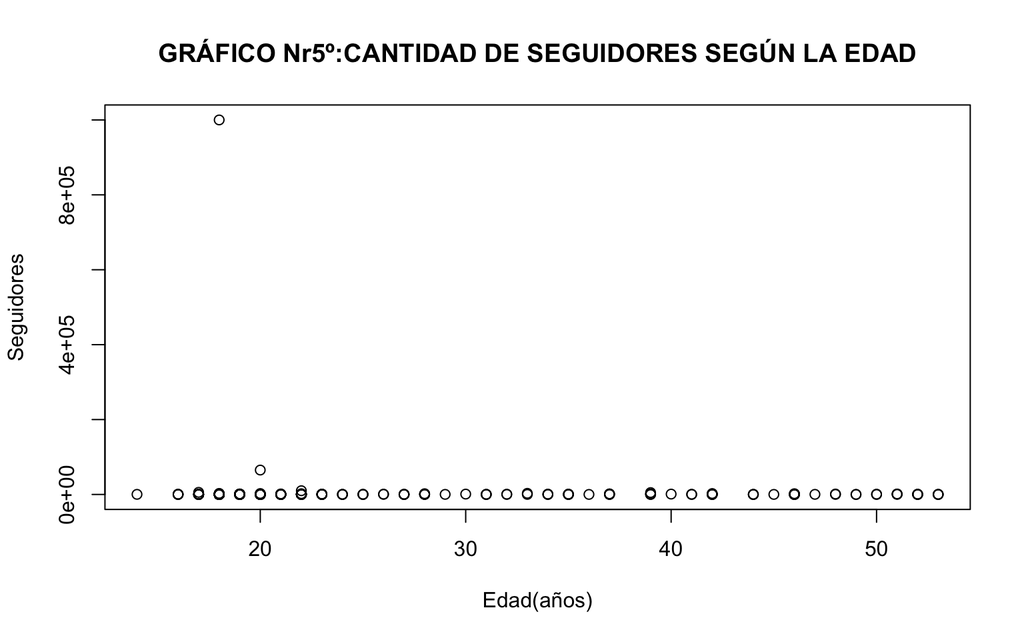

```r
plot(VDCnew$Seguidores~VDCnew$Edad, xlab = "Edad(años)", ylab = "Seguidores", main = "GRÁFICO Nr5º:CANTIDAD DE SEGUIDORES SEGÚN LA EDAD")
```

```r
cor(VDCnew$Edad,VDCnew$Seguidores)
```

```
## [1] -0.04522081
```

**Eliminamos usuarios que tengan una cantidad de seguidores mayor a 5000, ya que nos representa una dispersión muy amplia en nuestra data**

```r
VDCnew <- VDCnew %>% filter(Seguidores >= 1 & Seguidores <=5000)
```

```r
VDCnew %>% count(Seguidores) %>% arrange(-Seguidores)
```

```
## # A tibble: 110 × 2
##    Seguidores     n
##         <dbl> <int>
##  1       5000     1
##  2       3000     1
##  3       2700     1
##  4       2451     1
##  5       2400     1
##  6       2000     4
##  7       1500     2
##  8       1400     1
##  9       1394     1
## 10       1296     1
## # ℹ 100 more rows
```

**Cantidad de Seguidores luego de haberle aplicado filtros**

```r
r(mean(VDCnew$Seguidores, na.rm = T))
```

```
## [1] 374.25
```

```r
r(median(VDCnew$Seguidores, na.rm = T))
```

```
## [1] 200
```

```r
r(var(VDCnew$Seguidores, na.rm = T))
```

```
## [1] 308430.9
```

```r
r(sd(VDCnew$Seguidores, na.rm = T))
```

```
## [1] 555.37
```

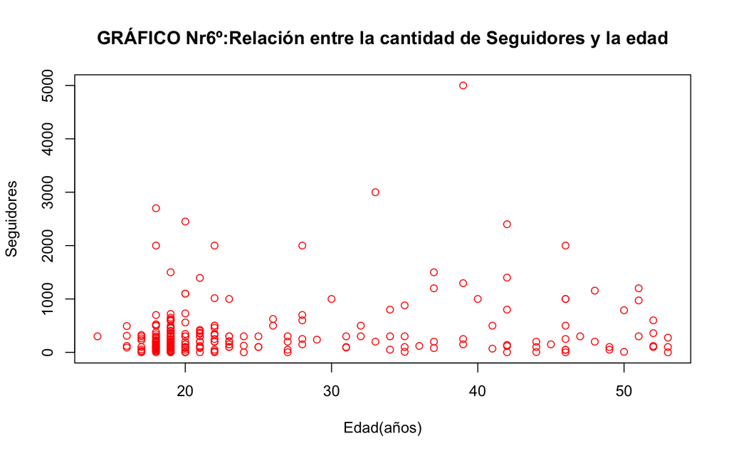

```r
plot(VDCnew$Seguidores~VDCnew$Edad, xlab = "Edad(años)", ylab = "Seguidores", main = "GRÁFICO Nr6º:Relación entre la cantidad de Seguidores y la edad", col = "red")
```

```r
cor(VDCnew$Edad,VDCnew$Seguidores)
```

```
## [1] 0.1852957
```

**Diagrama de cajas y bigotes entre la variable cantidad de seguidores y la generación**

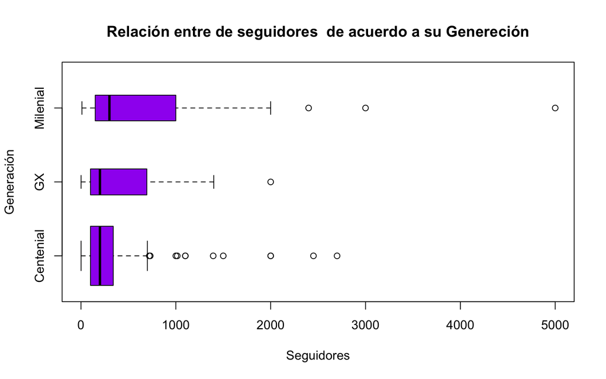

```r
boxplot(VDCnew$Seguidores ~ VDCnew$Generacion, horizontal = T,  main = "Relación entre de seguidores  de acuerdo a su Genereción", varwidth = T, xlab = "Seguidores", ylab = "Generación", col= c("purple"))
```

En la presente gráfica observamos datos atípicos en los maximos de las tres generaciones. Por otra parte, en cuanto a la mediana de cada generación, tanto la generación centenial, como X coinciden en la mediana. Si bien los centenial tienen una mayor cantidad de datos acomparación de las demas generaciones, sin embargo, los milenials en promedio tienen una mayor cantidad de seguirdores siendo 753.97.

```r
#Generación centenial: 12-27 años
#Generación milenial: 28-41 años
#Generación x: 42-53

#muestra la cantidad de datos de cada generación:
table(VDCnew$Generacion)
```

```
##
## Centenial        GX  Milenial
##       181        35        34
```

```r
generaciones = data.frame(VDCnew$Generacion, VDCnew$Seguidores)
```

```r
#Promedio - Milenial
milenial = generaciones$VDCnew.Seguidores[generaciones$VDCnew.Generacion == "Milenial"]
sum(milenial/34)
```

```
## [1] 753.9706
```

```r
#Promedio - GX
gx = generaciones$VDCnew.Seguidores[generaciones$VDCnew.Generacion == "GX"]
sum(gx/35)
```

```
## [1] 415.4857
```

```r
#Promedio - Centenial
centenial = generaciones$VDCnew.Seguidores[generaciones$VDCnew.Generacion == "Centenial"]
sum(centenial/180)
```

```
## [1] 296.5889
```

```r
#milenial = (VDCnew$Generacion, )
#milenial = VDCnew$Generacion[VDCnew$Generacion == "Milenial"]
#sum(milenial)
```

### **Tiempo de uso:**

hallaremos la moda de la variable tiempo de uso o momento del día en que utilizas más redes sociales….

```r
VDCnew %>% count(Tiempodeuso) %>% arrange(desc(n))
```

```
## # A tibble: 3 × 2
##   Tiempodeuso      n
##   <chr>        <int>
## 1 En la noche    178
## 2 En la tarde     56
## 3 En la mañana    16
```

Como resultado nos dió que…

```r
table(VDCnew$Tiempodeuso)
```

```
##
## En la mañana  En la noche  En la tarde
##           16          178           56
```

Como observamos, los usuarios usan durante mayor cantidad de tiempo redes sociales en la noche, en lugar de en el tarde o en la mañana. Esto se debe a que durante la tarde o la mañana pueden estar ocupados en el trabajo o en el colegio o en la universidad. Y en la noche a modo de relajación o descanso pueden pasar mas tiempo en redes sociales.

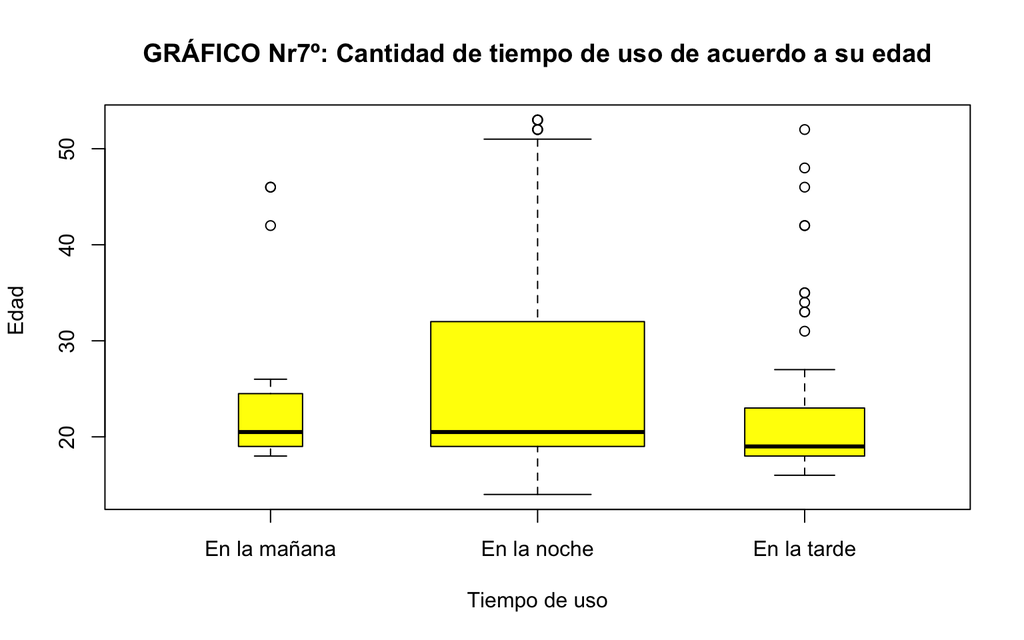

```r
boxplot(VDCnew$Edad ~ VDCnew$Tiempodeuso, horizontal = F,  main = "GRÁFICO Nr7º: Cantidad de tiempo de uso de acuerdo a su edad", varwidth = T, xlab = "Tiempo de uso", ylab = "Edad ", col = c("yellow"))
```

Observamos que este gráfico presenta valores atípicos o puntos en el extremo derecho. Con relación al tiempo de uso “en la mañana”, no presenta una dispersión significativamente grande. Sin embargo, en el caso de “en la noche”, la gráfica presenta whiskers o bigotes más largos, lo cual indica que los datos se extienden más lejos de la mediana y del rango intercuartílico. Esto sugiere una mayor variabilidad y dispersión de los datos en este grupo. Asimismo, observamos que tanto la mediana de “en la mañana” y “en la noche” coinciden.

La gráfica nos permite interpetar que dentro de la variable “en la noche” el 25% de datos por encima de la mediana presente una mayor concentración y se encuentra entre las personas de 20 a 30 años.

### **Cantidad de caracteres de la contraseña:**

```r
r(mean(VDCnew$Canticaracteres, na.rm = T))
```

```
## [1] 9.29
```

```r
r(median(VDCnew$Canticaracteres, na.rm = T))
```

```
## [1] 8.5
```

```r
r(var(VDCnew$Canticaracteres, na.rm = T))
```

```
## [1] 14.71
```

```r
r(sd(VDCnew$Canticaracteres, na.rm = T))
```

```
## [1] 3.84
```

hallaremos la moda de la variable canticaracteres….

```r
VDCnew%>% count(Canticaracteres) %>% arrange(desc(n))%>% arrange(desc(-Canticaracteres))
```

```
## # A tibble: 20 × 2
##    Canticaracteres     n
##              <dbl> <int>
##  1               2     2
##  2               3     5
##  3               4     7
##  4               5    14
##  5               6    16
##  6               7    19
##  7               8    62
##  8               9    17
##  9              10    45
## 10              11    11
## 11              12    20
## 12              13     7
## 13              14     8
## 14              15     7
## 15              16     1
## 16              17     2
## 17              18     2
## 18              20     2
## 19              21     2
## 20              41     1
```

Como resultado nos dió que…

- `moda es: 8`
- `numero de veces que se repite el número: 62`
- `Cantidad de caracteres de la contraseña VS Nivel de seguridad`

```r
table(VDCnew$Canticaracteres,VDCnew$Nseguridad)
```

```
##
##       1  2  3  4  5
##   2   1  0  1  0  0
##   3   0  0  1  2  2
##   4   0  1  2  3  1
##   5   2  0  4  4  4
##   6   1  0  3  7  5
##   7   0  1  3  8  7
##   8   2  2 18 30 10
##   9   1  1  6  6  3
##   10  0  3 15 14 13
##   11  0  0  4  5  2
##   12  0  1  6  9  4
##   13  1  0  0  3  3
##   14  0  0  1  3  4
##   15  0  0  4  2  1
##   16  0  0  0  0  1
##   17  0  0  0  1  1
##   18  0  0  0  0  2
##   20  0  0  0  1  1
##   21  0  0  0  2  0
##   41  0  0  0  0  1
```

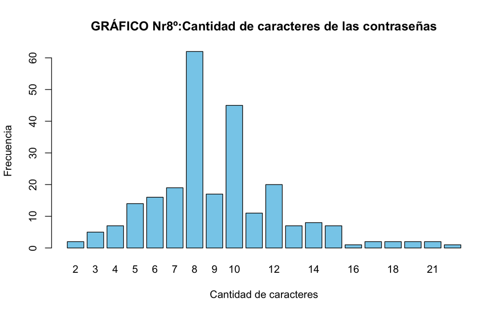

```r
barplot(table(VDCnew$Canticaracteres),
main = "GRÁFICO Nr8º:Cantidad de caracteres de las contraseñas",
xlab = "Cantidad de caracteres",
ylab = "Frecuencia",
col = c("skyblue"))
```

**Gráfico de dispersión: Relación entre la variable edad y cantidad de caracteres**

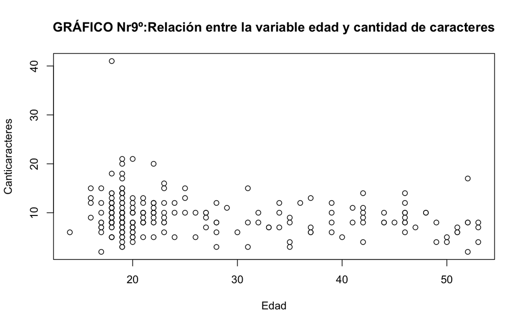

```r
plot(VDCnew$Canticaracteres~VDCnew$Edad, xlab = "Edad", ylab = "Canticaracteres", main = "GRÁFICO Nr9º:Relación entre la variable edad y cantidad de caracteres")
```

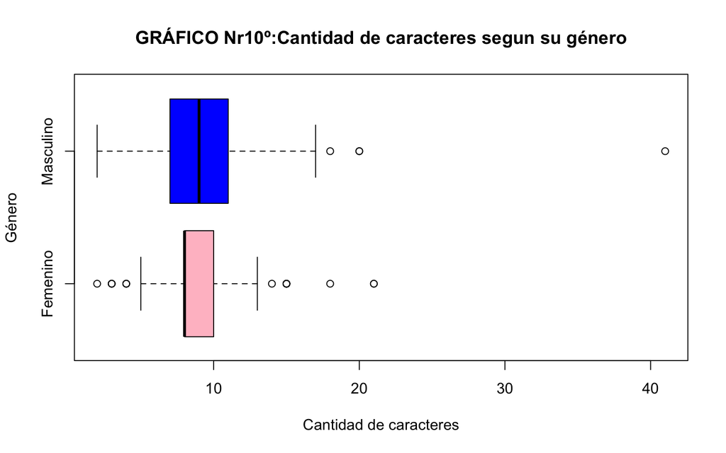

```r
boxplot(VDCnew$Canticaracteres~ VDCnew$Genero, horizontal = T, main = "GRÁFICO Nr10º:Cantidad de caracteres segun su género",col=c("pink","blue"), varwidth = T, xlab = "Cantidad de caracteres", ylab = "Género")
```

El género con mayor cantidad de caracteres en sus contraseñas de redes sociales es el masculino en comparación al género femenino.

### **Nivel de seguridad:**

```r
r(mean(VDCnew$Nseguridad,na.rm = T))
```

```
## [1] 3.82
```

```r
r(median(VDCnew$Nseguridad,na.rm = T))
```

```
## [1] 4
```

```r
r(var(VDCnew$Nseguridad,na.rm = T))
```

```
## [1] 0.94
```

```r
r(sd(VDCnew$Nseguridad,na.rm = T))
```

```
## [1] 0.97
```

```r
VDCnew%>% count(Nseguridad) %>% arrange(desc(n))
```

```
## # A tibble: 5 × 2
##   Nseguridad     n
##        <dbl> <int>
## 1          4   100
## 2          3    68
## 3          5    65
## 4          2     9
## 5          1     8
```

Como resultado nos dió que…

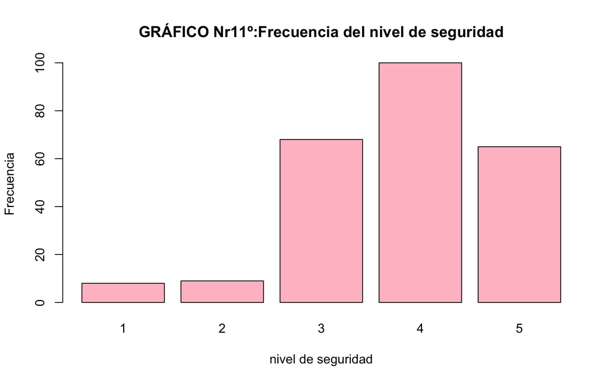

```r
barplot(table(VDCnew$Nseguridad),
main = "GRÁFICO Nr11º:Frecuencia del nivel de seguridad",
xlab = "nivel de seguridad",
ylab = "Frecuencia",
col = c("pink"))
```

El presente gráfico nos muestra que la mayoría de usuarios consideran que tienen un nivel de seguridad alto.

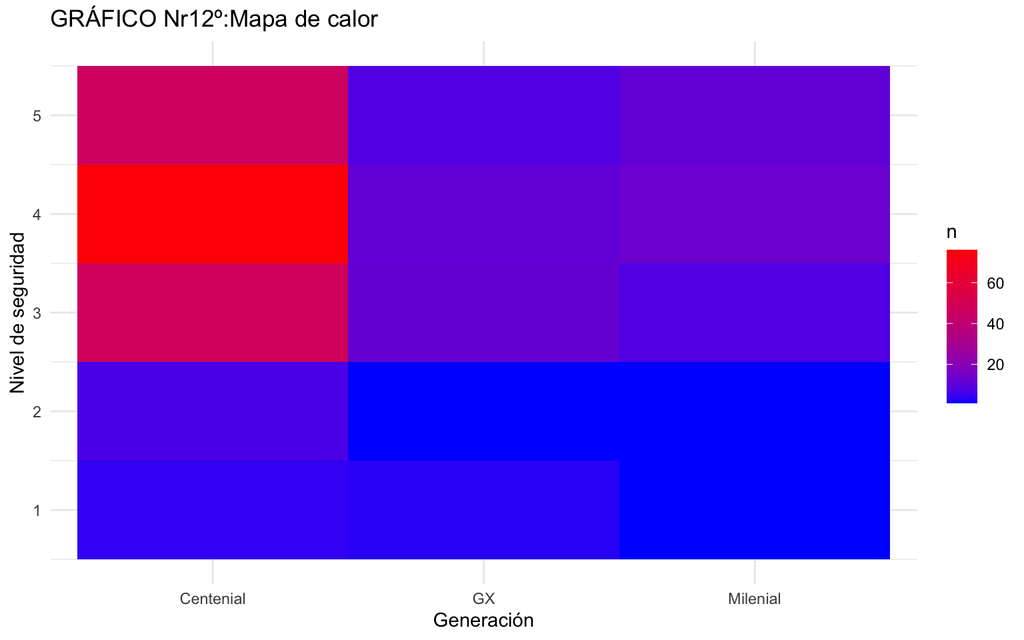

```r
variables_interes <- VDCnew%>%select(`Nseguridad`, `Generacion`)

frecuencias <- variables_interes %>%count(`Nseguridad`, `Generacion`)

ggplot(frecuencias, aes(x = `Generacion`,
                       y = `Nseguridad`,
                       fill = n)) +
  geom_tile() +
  scale_fill_gradient(low = "blue", high = "red") +
  theme_minimal() +
  labs(title = "GRÁFICO Nr12º:Mapa de calor",
       x = "Generación",
       y = "Nivel de seguridad")
```

Es importante tener en cuenta que las generalizaciones sobre una generación completa pueden ser simplificaciones excesivas, ya que cada individuo es único y sus características pueden variar ampliamente. Sin embargo, se han observado algunas tendencias generales en relación con la seguridad de las cuentas entre las generaciones.

Factores que podrían influir en la mayor preocupación por la seguridad de las cuentas en la generación centenial en comparación con la generación millenial y X:

- Crecimiento en la era digital
- Acceso a mejores recursos y programas de concienciación sobre seguridad en línea desde temprana edad.
- Mayor dependencia de las redes sociales

**Gráfico de dispersión: Relación entre la variable nivel de seguridad según la cantidad de caracteres**

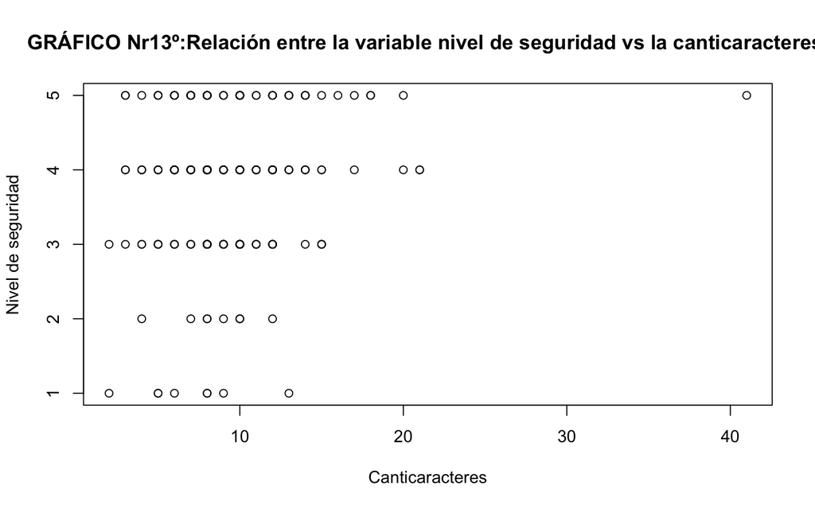

```r
plot(VDCnew$Nseguridad~VDCnew$Canticaracteres, xlab = "Canticaracteres", ylab = "Nivel de seguridad", main = "GRÁFICO Nr13º:Relación entre la variable nivel de seguridad vs la canticaracteres ")
```

Este gráfico nos lleva a reflexinar que si bien la seguridad para nuestro grupo de encuestados es importante, sin embargo la mayoría de personas opta por una cantidad de caracteres entre 8 a 12 caracteres aproximadamente, ya que al tener más caracteres si bien su contraseña será más segura, sin embargo, será más dificil recordarla y por ende la olvidará y tendrá que crear una nueva contraseña constantemente.

### **Uso de la misma contraseña para todas sus redes sociales:**

hallaremos la moda de la variable Usodecontraseña….

```r
VDCnew%>% count(Usodecontraseña) %>% arrange(desc(n))
```

```
## # A tibble: 3 × 2
##   Usodecontraseña     n
##   <chr>           <int>
## 1 Si                152
## 2 No                 93
## 3 <NA>                5
```

### **Cantidad de tiempo con la que cambian su contraseña:**

```r
r(mean(VDCnew$Tcambiocontraseña,na.rm = T))
```

```
## [1] 492.72
```

```r
r(median(VDCnew$Tcambiocontraseña,na.rm = T))
```

```
## [1] 30
```

```r
r(var(VDCnew$Tcambiocontraseña,na.rm = T))
```

```
## [1] 39962291
```

```r
r(sd(VDCnew$Tcambiocontraseña,na.rm = T))
```

```
## [1] 6321.57
```

```r
sqrt(39334097)
```

```
## [1] 6271.69
```

hallaremos la moda de la variable Tcambiocontraseña….

```r
VDCnew%>% count(Tcambiocontraseña) %>% arrange(desc(n))
```

```
## # A tibble: 34 × 2
##    Tcambiocontraseña     n
##                <dbl> <int>
##  1                30    42
##  2                 0    25
##  3                60    18
##  4               365    16
##  5                 1    15
##  6                 2    13
##  7                90    13
##  8               180    12
##  9                 3    11
## 10                 6    10
## # ℹ 24 more rows
```

Como resultado nos dió que…

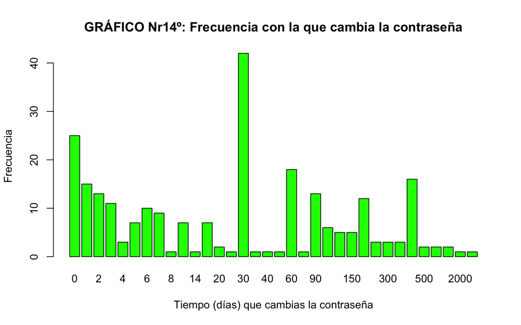

```r
barplot(table(VDCnew$Tcambiocontraseña),
main = "GRÁFICO Nr14º: Frecuencia con la que cambia la contraseña",
xlab = "Tiempo (días) que cambias la contraseña",
ylab = "Frecuencia",
col = c("green"))
```

*Hallamos su máximo*

```r
max(VDCnew$Tcambiocontraseña)
```

```
## [1] 1e+05
```

```r
VDCnew <- VDCnew %>% filter(Tcambiocontraseña >= 0 & Tcambiocontraseña <=2000)
```

Luego de haber aplicado el filtro sacamos los siguientes resultados….

```r
r(mean(VDCnew$Tcambiocontraseña,na.rm = T))
```

```
## [1] 93.09
```

```r
r(median(VDCnew$Tcambiocontraseña,na.rm = T))
```

```
## [1] 30
```

```r
r(var(VDCnew$Tcambiocontraseña,na.rm = T))
```

```
## [1] 36878.18
```

```r
r(sd(VDCnew$Tcambiocontraseña,na.rm = T))
```

```
## [1] 192.04
```

```r
sqrt(36878.18)
```

```
## [1] 192.0369
```

### **Cuenta hackeada:**

hallaremos la moda de la variable Cuenta hackeada….

```r
VDCnew%>% count(Cuentahackeada) %>% arrange(desc(n))
```

```
## # A tibble: 2 × 2
##   Cuentahackeada     n
##   <chr>          <int>
## 1 No               202
## 2 Si                47
```

Como resultado nos dió que…

- `moda es: no`
- `numero de veces que se repite el número: 202`

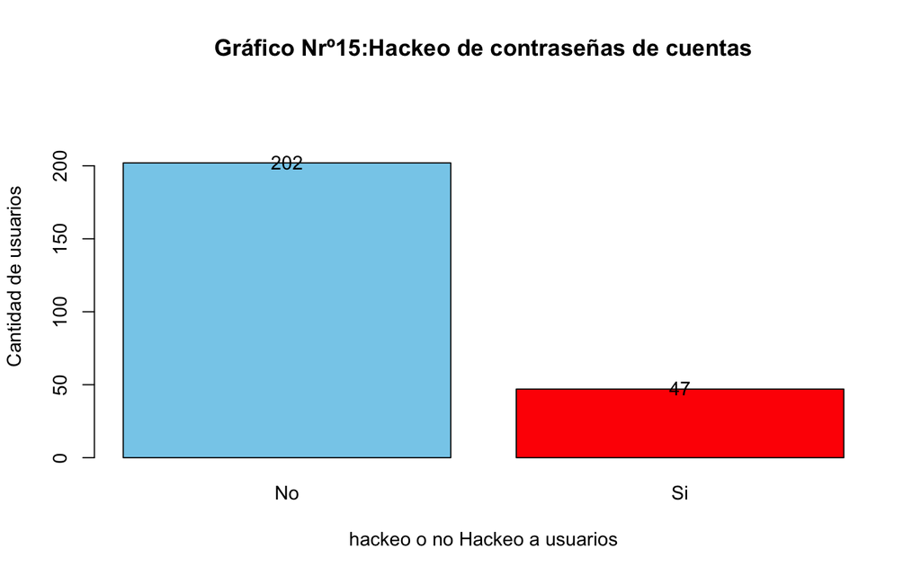

```r
Hackeos<-table(VDCnew$Cuentahackeada)
barp<-barplot( Hackeos,main="Gráfico Nrº15:Hackeo de contraseñas de cuentas",col=c("skyblue","red"),xlab = "hackeo o no Hackeo a usuarios", ylab = "Cantidad de usuarios",ylim=c(0,249) )
text(barp, Hackeos + 0.5, labels = Hackeos)
```

Observamos que 202 personas no han sido hackeadas, mientras que 47 si han sido hackeadas.

Dentro de los principales factores que influyen para que una cuenta de red social sea hackeada o no, son los siguientes:

- El uso de contraseñas débiles o predecibles es uno de los principales factores que facilitan el hackeo de una cuenta.
- Utilizar la misma contraseña en múltiples cuentas aumenta el riesgo a ser hackeado.

Ello nos lleva a pensar que las 47 personas que han sido hackeadas presentaban algunos de estos dos factores mencionados.

### **Número de notificaciones:**

```r
r(mean(VDCnew$Numnotificaciones,na.rm = T))
```

```
## [1] 12.17
```

```r
r(median(VDCnew$Numnotificaciones,na.rm = T))
```

```
## [1] 10
```

```r
r(var(VDCnew$Numnotificaciones,na.rm = T))
```

```
## [1] 216.44
```

```r
r(sd(VDCnew$Numnotificaciones,na.rm = T))
```

```
## [1] 14.71
```

hallaremos la moda de la variable Numnotificanes….

```r
VDCnew%>% count(Numnotificaciones) %>% arrange(desc(n))
```

```
## # A tibble: 28 × 2
##    Numnotificaciones     n
##                <dbl> <int>
##  1                10    48
##  2                20    31
##  3                 5    28
##  4                15    21
##  5                 2    17
##  6                 3    16
##  7                 8    16
##  8                 6    12
##  9                 1    11
## 10                12     9
## # ℹ 18 more rows
```

Como resultado nos dió que…

- `moda es: 10`
- `numero de veces que se repite el número: 48`

**observamos el comportamiento de la variable número de notificaciones**

```r
VDCnew %>% count(Numnotificaciones) %>% arrange(-Numnotificaciones)
```

```
## # A tibble: 28 × 2
##    Numnotificaciones     n
##                <dbl> <int>
##  1               100     4
##  2                69     1
##  3                58     1
##  4                50     2
##  5                45     1
##  6                40     2
##  7                38     1
##  8                30     2
##  9                25     1
## 10                23     2
## # ℹ 18 more rows
```

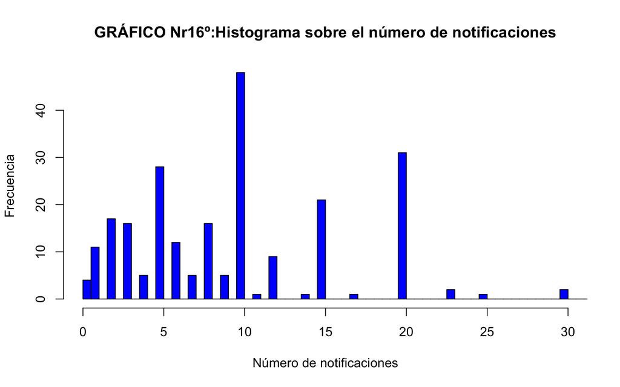

```r
hist(VDCnew$Numnotificaciones, xlim = c(0, 30), breaks = 300, main= "GRÁFICO Nr16º:Histograma sobre el número de notificaciones",xlab = "Número de notificaciones", ylab = "Frecuencia", col= "blue")
```

Estos nos lleva a inferir que al estar más pendientes de sus notificaciones, por ende pueden reaccionar más rápido al momento de ser hackeados, ya que si por a o b motivos hackearan tu cuenta o se presenta alguna anomalía extraña en alguna de tus cuentas de redes sociales en su mayoría google te manda un mensaje avisandote o advirtiendote ello.

Con en su mayoría de veces, me refiero a que, el principal objetivo del hacker es evitar que google y la persona que es hackeada se den cuenta de ello, por ende va intentar hackearte sin ser registrado.